# Analysis: learning session

Gamified Feedback in Adaptive Retrieval Practice

Maarten van der Velde & Gesa van den Broek

Last updated: 2024-07-11

# Setup

```r
library(here)
library(dplyr)
library(ggplot2)
library(scales)
library(patchwork)
library(stringr)
library(tidyr)
library(lme4)
library(lmerTest)
```

Helper functions for plots and tables:

```r
source(here("scripts", "00_visualisation_functions.R"))
```

Load processed data:

```r
d_learn <- readRDS(here("data", "processed", "d_learn.rds"))
```

```r
add_experiment_cols <- function (data) {
  data |>
    mutate(exp_order = case_when(
      gamified_first == 0 & exp_group == "score" ~ "Control—Score",
      gamified_first == 0 & exp_group == "both" ~ "Control—Both",
      gamified_first == 1 & exp_group == "score" ~ "Score—Control",
      gamified_first == 1 & exp_group == "both" ~ "Both—Control"
    )) |>
    mutate(type = ifelse(gamified, "Gamified", "Control"))
}
```

# Does gamification change performance during practice?

## Accuracy

### Prepare data

```r
d_learn_acc <- d_learn |>
  filter(!study_trial) |>
  group_by(subject, exp_group, block, condition, gamified, gamified_first) |>
  summarise(accuracy = mean(correct))
```

```
'condition', 'gamified'. You can override using the `.groups` argument.
```

```r
d_learn_acc_agg <- d_learn_acc |>
  group_by(block, condition, gamified, gamified_first, exp_group) |>
  summarise(acc = mean(accuracy, na.rm = T),
            acc_se = sd(accuracy, na.rm = T)/sqrt(n())) |>
  ungroup() |>
  add_experiment_cols()
```

```
'gamified_first'. You can override using the `.groups` argument.
```

### Visualise data

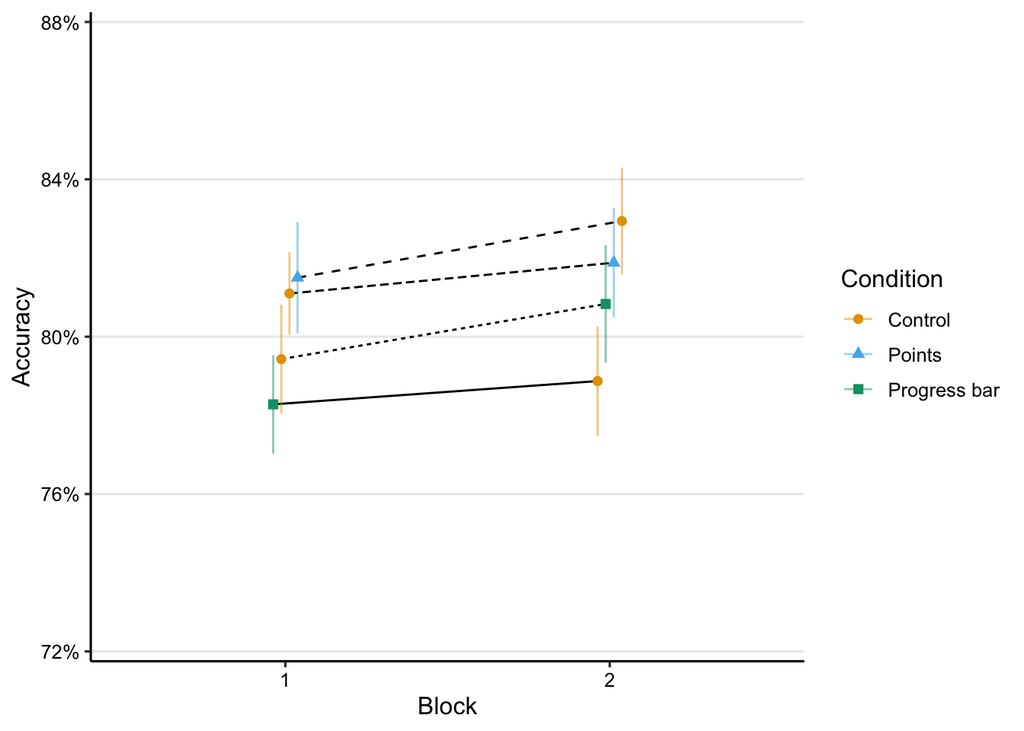

```r
p_learn_acc <- plot_data(d_learn_acc_agg, acc, acc_se, "Accuracy") +
  scale_y_continuous(limits = c(.725, .875), labels = scales::percent_format())

p_learn_acc
```

### Fit model

Prepare data for modelling by mean-centering categorical predictors:

```r
d_learn_m <- d_learn |>
  filter(!study_trial) |>
  mutate(exp_group_c = ifelse(exp_group == "score", 0, 1),
         exp_group_c = exp_group_c - mean(exp_group_c),
         gamified_first_c = gamified_first - mean(gamified_first))
```

```r
m_learn_acc <- glmer(correct ~ gamified +
                       gamified:exp_group_c +
                       gamified:gamified_first_c +
                       gamified:gamified_first_c:exp_group_c +
                       (1 | subject) + (1 | fact),
                     family = "binomial",
                     data = d_learn_m)

summary(m_learn_acc)
```

```
Generalized linear mixed model fit by maximum likelihood (Laplace
  Approximation) [glmerMod]
 Family: binomial  ( logit )
Formula:
correct ~ gamified + gamified:exp_group_c + gamified:gamified_first_c +
    gamified:gamified_first_c:exp_group_c + (1 | subject) + (1 |      fact)
   Data: d_learn_m

     AIC      BIC   logLik deviance df.resid
 38686.5  38772.8 -19333.3  38666.5    41479

Scaled residuals:
    Min      1Q  Median      3Q     Max
-5.4230  0.2697  0.4166  0.5308  0.8948

Random effects:
 Groups  Name        Variance Std.Dev.
 subject (Intercept) 0.2932   0.5415
 fact    (Intercept) 0.1178   0.3432
Number of obs: 41489, groups:  subject, 166; fact, 78

Fixed effects:
                                            Estimate Std. Error z value
(Intercept)                                 1.621184   0.060640  26.735
gamifiedTRUE                               -0.007472   0.025932  -0.288
gamifiedFALSE:exp_group_c                  -0.181824   0.092172  -1.973
gamifiedTRUE:exp_group_c                   -0.160723   0.092242  -1.742
gamifiedFALSE:gamified_first_c              0.069727   0.092386   0.755
gamifiedTRUE:gamified_first_c              -0.079241   0.092419  -0.857
gamifiedFALSE:exp_group_c:gamified_first_c -0.245058   0.185121  -1.324
gamifiedTRUE:exp_group_c:gamified_first_c  -0.181772   0.185123  -0.982
                                           Pr(>|z|)
(Intercept)                                  <2e-16 ***
gamifiedTRUE                                 0.7732
gamifiedFALSE:exp_group_c                    0.0485 *
gamifiedTRUE:exp_group_c                     0.0814 .
gamifiedFALSE:gamified_first_c               0.4504
gamifiedTRUE:gamified_first_c                0.3912
gamifiedFALSE:exp_group_c:gamified_first_c   0.1856
gamifiedTRUE:exp_group_c:gamified_first_c    0.3261
---
Signif. codes:  0 '***' 0.001 '**' 0.01 '*' 0.05 '.' 0.1 ' ' 1

Correlation of Fixed Effects:
              (Intr) gmTRUE gmfdFALSE:x__ gmfdTRUE:x__ gmfdFALSE:g__
gamifidTRUE   -0.215
gmfdFALSE:x__ -0.014  0.017
gmfdTRUE:x__  -0.008 -0.012  0.841
gmfdFALSE:g__ -0.011  0.000 -0.010        -0.004
gmfdTRUE:g__  -0.014  0.001 -0.004        -0.009        0.842
gFALSE:__:_   -0.008  0.011 -0.017        -0.016       -0.019
gTRUE:__:__   -0.003 -0.009 -0.016        -0.018       -0.010
              gmfdTRUE:g__ gFALSE:__:
gamifidTRUE
gmfdFALSE:x__
gmfdTRUE:x__
gmfdFALSE:g__
gmfdTRUE:g__
gFALSE:__:_   -0.010
gTRUE:__:__   -0.016        0.842
```

```r
print_model_table(m_learn_acc)
```

| Effect | Estimate | SE | z-value | p-value |
| --- | --- | --- | --- | --- |
| Intercept (Control) | 1.62 | 0.06 | 26.73 | <.001 |
| Gamification | -0.01 | 0.03 | -0.29 | .773 |
| Type of gamification (Progress bar - Points) | -0.16 | 0.09 | -1.74 | .081 |
| Type of gamification on Control (Progress bar - Points) | -0.18 | 0.09 | -1.97 | .049 |
| Block on gamification (1 - 2) | -0.08 | 0.09 | -0.86 | .391 |
| Block on Control (2 - 1) | 0.07 | 0.09 | 0.75 | .450 |
| Type of gamification; block difference (Block 1 - Block 2) | -0.18 | 0.19 | -0.98 | .326 |
| Type of gamification on Control; block difference (Block 2 - Block 1) | -0.25 | 0.19 | -1.32 | .186 |

### Fitted values

```r
d_model_fit <- crossing(
  gamified = FALSE,
  exp_group_c = sort(unique(d_learn_m$exp_group_c)),
  gamified_first_c = 0
)

d_model_fit$model_fit <- predict(m_learn_acc,
                                 newdata = d_model_fit,
                                 re.form = NA,
                                 type = "response")

d_model_fit
```

| gamified | exp_group_c | gamified_first_c | model_fit |
| --- | --- | --- | --- |
| FALSE | -0.4703174 | 0 | 0.8464077 |
| FALSE | 0.5296826 | 0 | 0.8212552 |

### Visualise fitted model

```r
p_learn_acc_m <- plot_model_fit(m_learn_acc, d_learn_m, y_lab = "Accuracy") +
  scale_y_continuous(limits = c(.75, .90), labels = scales::percent_format(accuracy = .1))
```

```
  block    condition gamified gamified_first exp_group gamified_first_c
1     1      Control    FALSE          FALSE      both       -0.5320687
2     1      Control    FALSE          FALSE     score       -0.5320687
3     1       Points     TRUE           TRUE     score        0.4679313
4     1 Progress bar     TRUE           TRUE      both        0.4679313
5     2      Control    FALSE           TRUE      both        0.4679313
6     2      Control    FALSE           TRUE     score        0.4679313
7     2       Points     TRUE          FALSE     score       -0.5320687
8     2 Progress bar     TRUE          FALSE      both       -0.5320687
  exp_group_c  pred_val     exp_order     type
1   0.5296826 0.8258994  Control—Both  Control
2  -0.4703174 0.8331719 Control—Score  Control
3  -0.4703174 0.8445168 Score—Control Gamified
4   0.5296826 0.8094510  Both—Control Gamified
5   0.5296826 0.8170913  Both—Control  Control
6  -0.4703174 0.8573262 Score—Control  Control
7  -0.4703174 0.8436944 Control—Score Gamified
8   0.5296826 0.8350666  Control—Both Gamified
```

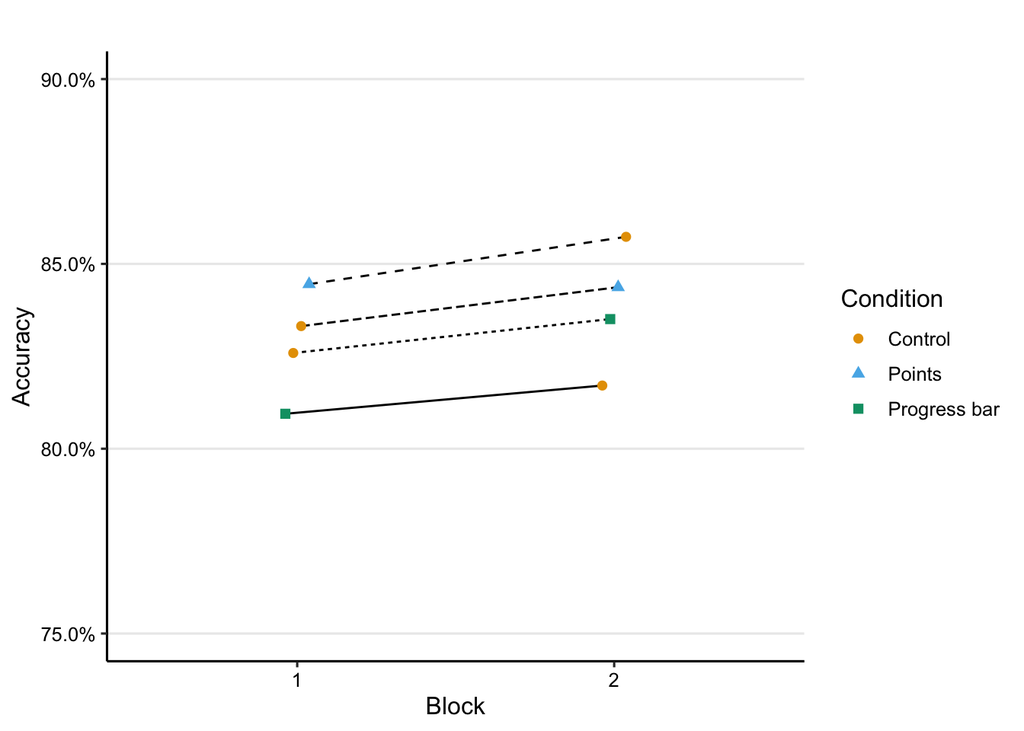

```r
p_learn_acc_m
```

## Response time

Response time on correct answers only.

### Prepare data

To keep the visualisation of average response times by condition simple, we calculate the median RT per participant, and then take the mean and SD of these medians (which are themselves roughly normally distributed).

```r
d_learn_rt <- d_learn |>
  filter(!study_trial) |>
  filter(correct) |>
  mutate(rt = rt / 1000) |>
  group_by(subject, exp_group, block, condition, gamified, gamified_first) |>
  summarise(rt_median = median(rt, na.rm = TRUE))
```

```
'condition', 'gamified'. You can override using the `.groups` argument.
```

```r
d_learn_rt_agg <- d_learn_rt |>
  group_by(block, condition, gamified, gamified_first, exp_group) |>
  summarise(rt_mean = mean(rt_median, na.rm = T),
            rt_se = sd(rt_median, na.rm = T)/sqrt(n())) |>
  ungroup() |>
  add_experiment_cols()
```

```
'gamified_first'. You can override using the `.groups` argument.
```

### Visualise data

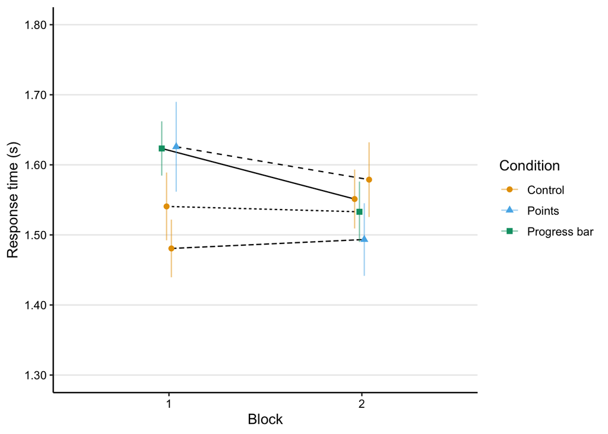

```r
p_learn_rt <- plot_data(d_learn_rt_agg, rt_mean, rt_se, "Response time (s)") +
  scale_y_continuous(limits = c(1.3, 1.8), labels = scales::comma_format())

p_learn_rt
```

### Fit model

Since RT data is not normally distributed, we fit a lognormal model to the response times. (See https://bbolker.github.io/mixedmodels-misc/glmmFAQ.html#gamma-glmms .) Prepare data for modelling by mean-centering categorical predictors:

```r
d_learn_rt_m <- d_learn |>
  filter(!study_trial) |>
  filter(correct) |>
  mutate(log_rt = log(rt / 1000)) |>
  mutate(exp_group_c = ifelse(exp_group == "score", 0, 1),
         exp_group_c = exp_group_c - mean(exp_group_c),
         gamified_first_c = gamified_first - mean(gamified_first)
         )
```

```r
m_learn_rt <- lmer(log_rt ~ gamified +
                      gamified:exp_group_c +
                      gamified:gamified_first_c +
                      gamified:gamified_first_c:exp_group_c +
                      (1 | subject) + (1 | fact),
                    data = d_learn_rt_m)

summary(m_learn_rt)
```

```
Linear mixed model fit by REML. t-tests use Satterthwaite's method [
lmerModLmerTest]
Formula:
log_rt ~ gamified + gamified:exp_group_c + gamified:gamified_first_c +
    gamified:gamified_first_c:exp_group_c + (1 | subject) + (1 |      fact)
   Data: d_learn_rt_m

REML criterion at convergence: 58081.7

Scaled residuals:
     Min       1Q   Median       3Q      Max
-15.6337  -0.5696  -0.1470   0.4864   4.8537

Random effects:
 Groups   Name        Variance Std.Dev.
 subject  (Intercept) 0.03589  0.1895
 fact     (Intercept) 0.01190  0.1091
 Residual             0.32134  0.5669
Number of obs: 33657, groups:  subject, 166; fact, 78

Fixed effects:
                                             Estimate Std. Error         df
(Intercept)                                 4.837e-01  1.973e-02  2.287e+02
gamifiedTRUE                                1.734e-02  6.240e-03  3.347e+04
gamifiedFALSE:exp_group_c                   9.712e-03  3.077e-02  1.754e+02
gamifiedTRUE:exp_group_c                    4.371e-02  3.078e-02  1.757e+02
gamifiedFALSE:gamified_first_c              1.335e-03  3.084e-02  1.753e+02
gamifiedTRUE:gamified_first_c               7.474e-02  3.085e-02  1.754e+02
gamifiedFALSE:exp_group_c:gamified_first_c -3.774e-02  6.175e-02  1.755e+02
gamifiedTRUE:exp_group_c:gamified_first_c  -2.206e-02  6.175e-02  1.754e+02
                                           t value Pr(>|t|)
(Intercept)                                 24.522  < 2e-16 ***
gamifiedTRUE                                 2.779  0.00546 **
gamifiedFALSE:exp_group_c                    0.316  0.75264
gamifiedTRUE:exp_group_c                     1.420  0.15738
gamifiedFALSE:gamified_first_c               0.043  0.96553
gamifiedTRUE:gamified_first_c                2.423  0.01640 *
gamifiedFALSE:exp_group_c:gamified_first_c  -0.611  0.54185
gamifiedTRUE:exp_group_c:gamified_first_c   -0.357  0.72138
---
Signif. codes:  0 '***' 0.001 '**' 0.01 '*' 0.05 '.' 0.1 ' ' 1

Correlation of Fixed Effects:
              (Intr) gmTRUE gmfdFALSE:x__ gmfdTRUE:x__ gmfdFALSE:g__
gamifidTRUE   -0.158
gmfdFALSE:x__ -0.020  0.000
gmfdTRUE:x__  -0.020  0.000  0.917
gmfdFALSE:g__ -0.017  0.005 -0.003        -0.004
gmfdTRUE:g__  -0.016  0.006 -0.004        -0.003        0.918
gFALSE:__:_   -0.002 -0.002 -0.022        -0.021       -0.025
gTRUE:__:__   -0.003  0.002 -0.021        -0.018       -0.025
              gmfdTRUE:g__ gFALSE:__:
gamifidTRUE
gmfdFALSE:x__
gmfdTRUE:x__
gmfdFALSE:g__
gmfdTRUE:g__
gFALSE:__:_   -0.025
gTRUE:__:__   -0.025        0.917
```

```r
print_model_table(m_learn_rt)
```

| Effect | Estimate | SE | df | t-value | p-value |
| --- | --- | --- | --- | --- | --- |
| Intercept (Control) | 0.484 | 0.020 | 228.75 | 24.52 | <.001 |
| Gamification | 0.017 | 0.006 | 33,473.10 | 2.78 | .005 |
| Type of gamification (Progress bar - Points) | 0.044 | 0.031 | 175.68 | 1.42 | .157 |
| Type of gamification on Control (Progress bar - Points) | 0.010 | 0.031 | 175.40 | 0.32 | .753 |
| Block on gamification (1 - 2) | 0.075 | 0.031 | 175.37 | 2.42 | .016 |
| Block on Control (2 - 1) | 0.001 | 0.031 | 175.29 | 0.04 | .966 |
| Type of gamification; block difference (Block 1 - Block 2) | -0.022 | 0.062 | 175.44 | -0.36 | .721 |
| Type of gamification on Control; block difference (Block 2 - Block 1) | -0.038 | 0.062 | 175.48 | -0.61 | .542 |

### Fitted values

```r
d_model_fit <- crossing(
  gamified = c(FALSE, TRUE),
  exp_group_c = 0,
  gamified_first_c = 0
)

d_model_fit$model_fit <- predict(m_learn_rt,
                                 newdata = d_model_fit,
                                 re.form = NA,
                                 type = "response") |>
  exp() # Transform logRT to RT

d_model_fit
```

| gamified | exp_group_c | gamified_first_c | model_fit |
| --- | --- | --- | --- |
| FALSE | 0 | 0 | 1.622120 |
| TRUE | 0 | 0 | 1.650493 |

```r
d_model_fit <- crossing(
  gamified = c(FALSE, TRUE),
  exp_group_c = 0,
  gamified_first_c = sort(unique(d_learn_rt_m$gamified_first_c))
)

d_model_fit$model_fit <- predict(m_learn_rt,
                                 newdata = d_model_fit,
                                 re.form = NA,
                                 type = "response") |>
  exp() # Transform logRT to RT

d_model_fit
```

| gamified | exp_group_c | gamified_first_c | model_fit |
| --- | --- | --- | --- |
| FALSE | 0 | -0.5311822 | 1.620971 |
| FALSE | 0 | 0.4688178 | 1.623136 |
| TRUE | 0 | -0.5311822 | 1.586247 |
| TRUE | 0 | 0.4688178 | 1.709353 |

### Visualise fitted model

```r
p_learn_rt_m <- plot_model_fit(m_learn_rt, d_learn_rt_m, exp_trans = TRUE, y_lab = "Response time (s)") +
  scale_y_continuous(limits = c(1.4, 1.9), labels = scales::comma_format())
```

```
  block    condition gamified gamified_first exp_group gamified_first_c
1     1      Control    FALSE          FALSE      both       -0.5311822
2     1      Control    FALSE          FALSE     score       -0.5311822
3     1       Points     TRUE           TRUE     score        0.4688178
4     1 Progress bar     TRUE           TRUE      both        0.4688178
5     2      Control    FALSE           TRUE      both        0.4688178
6     2      Control    FALSE           TRUE     score        0.4688178
7     2       Points     TRUE          FALSE     score       -0.5311822
8     2 Progress bar     TRUE          FALSE      both       -0.5311822
  exp_group_c pred_val     exp_order     type
1   0.5378079 1.647124  Control—Both  Control
2  -0.4621921 1.598827 Control—Score  Control
3  -0.4621921 1.683192 Score—Control Gamified
4   0.5378079 1.740307  Both—Control Gamified
5   0.5378079 1.616182  Both—Control  Control
6  -0.4621921 1.629135 Score—Control  Control
7  -0.4621921 1.546128 Control—Score Gamified
8   0.5378079 1.634243  Control—Both Gamified
```

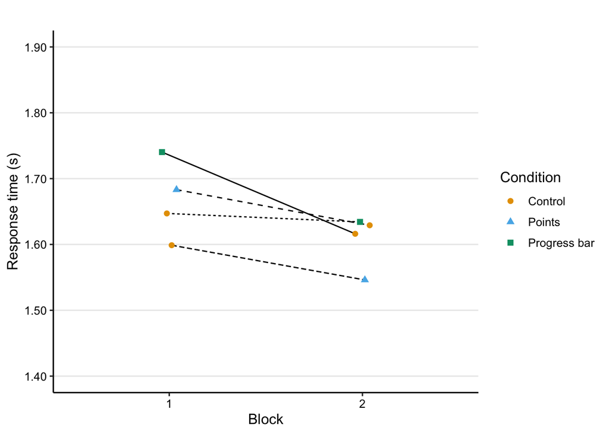

```r
p_learn_rt_m
```

## Total score

The total score is the number of points after the last trial in a block.

### Prepare data

```r
d_learn_score <- d_learn |>
  group_by(subject, exp_group, block, condition, gamified, gamified_first) |>
  slice(n())

d_learn_score_agg <- d_learn_score |>
  group_by(block, condition, gamified, gamified_first, exp_group) |>
  summarise(feedback_score_mean = mean(feedback_score, na.rm = T),
            feedback_score_se = sd(feedback_score, na.rm = T)/sqrt(n())) |>
  ungroup() |>
  add_experiment_cols()
```

```
'gamified_first'. You can override using the `.groups` argument.
```

### Visualise data

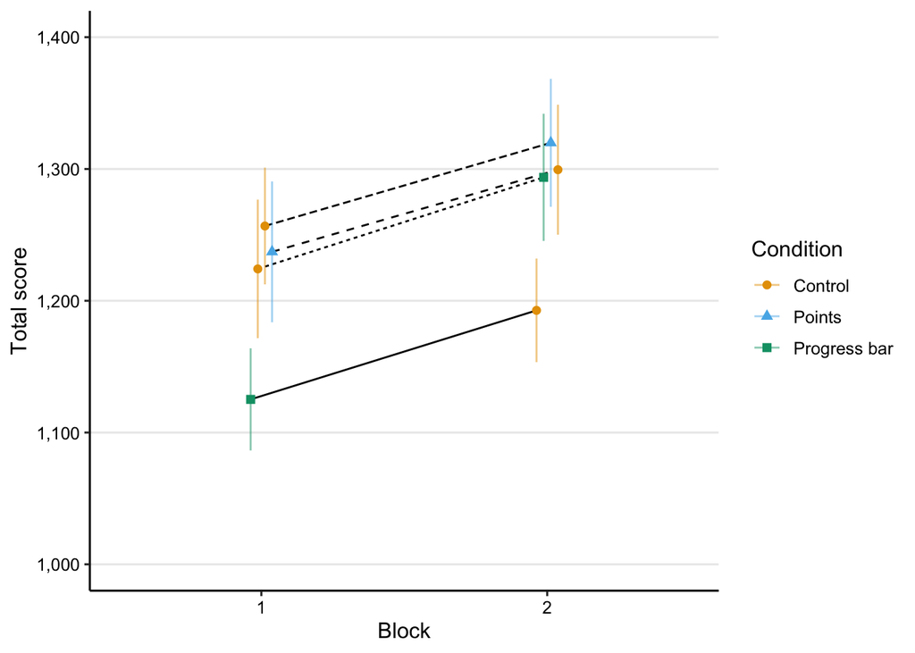

```r
p_learn_score <- plot_data(d_learn_score_agg, feedback_score_mean, feedback_score_se, "Total score") +
  scale_y_continuous(limits = c(1000, 1400), labels = scales::comma_format())

p_learn_score
```

Distribution of scores:

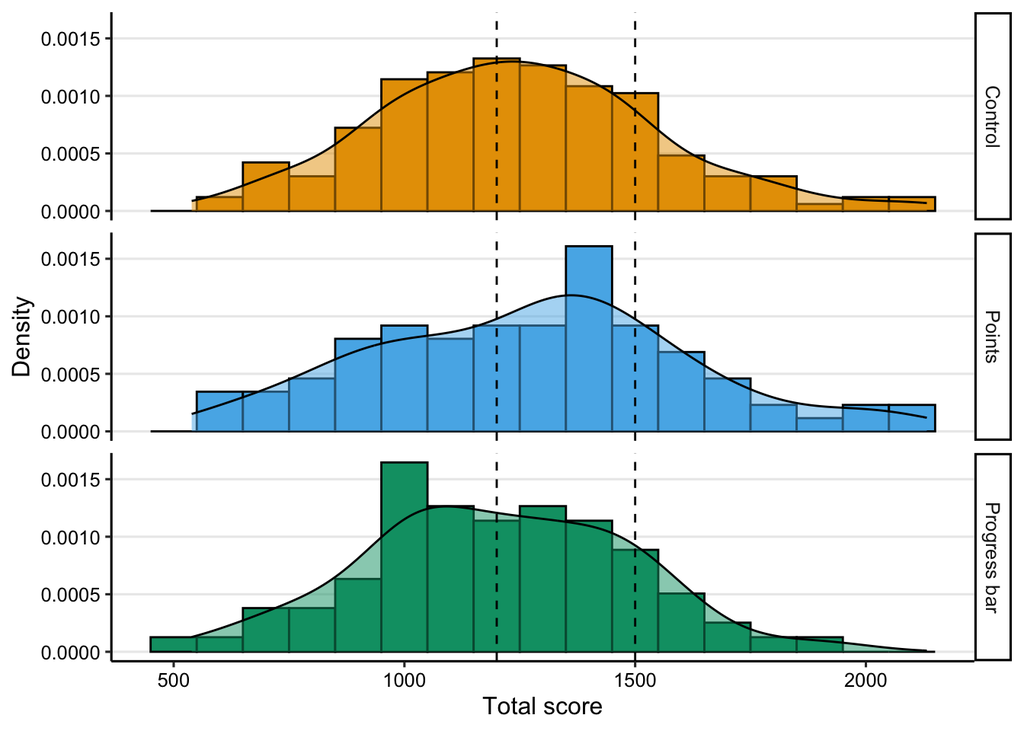

```r
p_learn_score_dist <- ggplot(d_learn_score, aes(x = feedback_score, fill = condition)) +
  facet_grid(condition ~ .) +
  geom_histogram(aes(y=..density..), colour = "black", binwidth = 100) +
  geom_density(alpha = .5) +
  geom_vline(xintercept = c(1200, 1500), lty = 2) +
  scale_fill_manual(values = col_condition) +
  scale_colour_manual(values = col_condition) +
  guides(fill = "none",
         colour = "none") +
  labs(x = "Total score",
       y = "Density") +
  theme_paper

p_learn_score_dist
```

### Fit model

Prepare data for modelling by mean-centering categorical predictors:

```r
d_learn_score_m <- d_learn_score |>
  ungroup() |>
  mutate(exp_group_c = ifelse(exp_group == "score", 0, 1),
         exp_group_c = exp_group_c - mean(exp_group_c),
         gamified_first_c = gamified_first - mean(gamified_first))
```

```r
m_learn_score <- lmer(feedback_score ~ gamified +
                       gamified:exp_group_c +
                       gamified:gamified_first_c +
                       gamified:gamified_first_c:exp_group_c +
                       (1 | subject),
                     data = d_learn_score_m)

summary(m_learn_score)
```

```
Linear mixed model fit by REML. t-tests use Satterthwaite's method [
lmerModLmerTest]
Formula:
feedback_score ~ gamified + gamified:exp_group_c + gamified:gamified_first_c +
    gamified:gamified_first_c:exp_group_c + (1 | subject)
   Data: d_learn_score_m

REML criterion at convergence: 4534.5

Scaled residuals:
     Min       1Q   Median       3Q      Max
-2.48749 -0.54087 -0.03256  0.49006  2.49651

Random effects:
 Groups   Name        Variance Std.Dev.
 subject  (Intercept) 67352    259.5
 Residual             25509    159.7
Number of obs: 332, groups:  subject, 166

Fixed effects:
                                           Estimate Std. Error       df t value
(Intercept)                                1245.256     23.652  212.312  52.649
gamifiedTRUE                                 -4.856     17.531  162.000  -0.277
gamifiedFALSE:exp_group_c                   -72.770     47.359  212.312  -1.537
gamifiedTRUE:exp_group_c                    -72.704     47.359  212.312  -1.535
gamifiedFALSE:gamified_first_c                7.425     47.473  212.312   0.156
gamifiedTRUE:gamified_first_c              -123.533     47.473  212.312  -2.602
gamifiedFALSE:exp_group_c:gamified_first_c  -74.168     95.059  212.312  -0.780
gamifiedTRUE:exp_group_c:gamified_first_c   -85.754     95.059  212.312  -0.902
                                           Pr(>|t|)
(Intercept)                                 < 2e-16 ***
gamifiedTRUE                                0.78215
gamifiedFALSE:exp_group_c                   0.12589
gamifiedTRUE:exp_group_c                    0.12623
gamifiedFALSE:gamified_first_c              0.87586
gamifiedTRUE:gamified_first_c               0.00992 **
gamifiedFALSE:exp_group_c:gamified_first_c  0.43613
gamifiedTRUE:exp_group_c:gamified_first_c   0.36802
---
Signif. codes:  0 '***' 0.001 '**' 0.01 '*' 0.05 '.' 0.1 ' ' 1

Correlation of Fixed Effects:
              (Intr) gmTRUE gmfdFALSE:x__ gmfdTRUE:x__ gmfdFALSE:g__
gamifidTRUE   -0.371
gmfdFALSE:x__  0.000  0.000
gmfdTRUE:x__   0.000  0.000  0.725
gmfdFALSE:g__  0.000  0.000 -0.004        -0.003
gmfdTRUE:g__   0.000  0.000 -0.003        -0.004        0.725
gFALSE:__:_   -0.004  0.002  0.000         0.000        0.001
gTRUE:__:__   -0.003 -0.002  0.000         0.000        0.001
              gmfdTRUE:g__ gFALSE:__:
gamifidTRUE
gmfdFALSE:x__
gmfdTRUE:x__
gmfdFALSE:g__
gmfdTRUE:g__
gFALSE:__:_    0.001
gTRUE:__:__    0.001        0.725
```

```r
print_model_table(m_learn_score)
```

| Effect | Estimate | SE | df | t-value | p-value |
| --- | --- | --- | --- | --- | --- |
| Intercept (Control) | 1,245.256 | 23.652 | 212.31 | 52.65 | <.001 |
| Gamification | -4.856 | 17.531 | 162.00 | -0.28 | .782 |
| Type of gamification (Progress bar - Points) | -72.704 | 47.359 | 212.31 | -1.54 | .126 |
| Type of gamification on Control (Progress bar - Points) | -72.770 | 47.359 | 212.31 | -1.54 | .126 |
| Block on gamification (1 - 2) | -123.533 | 47.473 | 212.31 | -2.60 | .010 |
| Block on Control (2 - 1) | 7.425 | 47.473 | 212.31 | 0.16 | .876 |
| Type of gamification; block difference (Block 1 - Block 2) | -85.754 | 95.059 | 212.31 | -0.90 | .368 |
| Type of gamification on Control; block difference (Block 2 - Block 1) | -74.168 | 95.059 | 212.31 | -0.78 | .436 |

### Fitted values

```r
d_model_fit <- crossing(
  gamified = TRUE,
  exp_group_c = 0,
  gamified_first_c = sort(unique(d_learn_score_m$gamified_first_c))
)

d_model_fit$model_fit <- predict(m_learn_score,
                                 newdata = d_model_fit,
                                 re.form = NA,
                                 type = "response")

d_model_fit
```

| gamified | exp_group_c | gamified_first_c | model_fit |
| --- | --- | --- | --- |
| TRUE | 0 | -0.5421687 | 1307.376 |
| TRUE | 0 | 0.4578313 | 1183.843 |

### Visualise fitted model

```r
p_learn_score_m <- plot_model_fit(m_learn_score, d_learn_score_m, y_lab = "Total score") +
  scale_y_continuous(limits = c(1000, 1500))
```

```
  block    condition gamified gamified_first exp_group gamified_first_c
1     1      Control    FALSE          FALSE      both       -0.5421687
2     1      Control    FALSE          FALSE     score       -0.5421687
3     1       Points     TRUE           TRUE     score        0.4578313
4     1 Progress bar     TRUE           TRUE      both        0.4578313
5     2      Control    FALSE           TRUE      both        0.4578313
6     2      Control    FALSE           TRUE     score        0.4578313
7     2       Points     TRUE          FALSE     score       -0.5421687
8     2 Progress bar     TRUE          FALSE      both       -0.5421687
  exp_group_c pred_val     exp_order     type
1   0.5240964 1224.167  Control—Both  Control
2  -0.4759036 1256.725 Control—Score  Control
3  -0.4759036 1237.128 Score—Control Gamified
4   0.5240964 1125.163  Both—Control Gamified
5   0.5240964 1192.721  Both—Control  Control
6  -0.4759036 1299.447 Score—Control  Control
7  -0.4759036 1319.850 Control—Score Gamified
8   0.5240964 1293.639  Control—Both Gamified
```

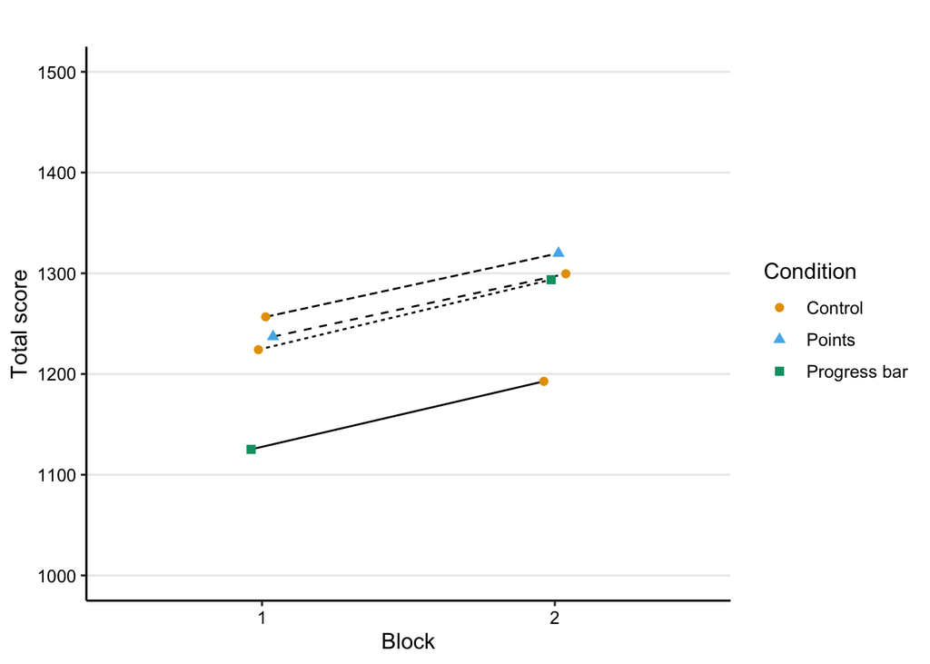

```r
p_learn_score_m
```

## Number of words practiced

### Prepare data

```r
d_learn_words <- d_learn |>
  group_by(subject, exp_group, block, condition, gamified, gamified_first) |>
  summarise(words_seen = n_distinct(fact))
```

```
'condition', 'gamified'. You can override using the `.groups` argument.
```

```r
d_learn_words_agg <- d_learn_words |>
  group_by(block, condition, gamified, gamified_first, exp_group) |>
  summarise(words_mean = mean(words_seen, na.rm = T),
            words_se = sd(words_seen, na.rm = T)/sqrt(n())) |>
  ungroup() |>
  add_experiment_cols()
```

```
'gamified_first'. You can override using the `.groups` argument.
```

### Visualise data

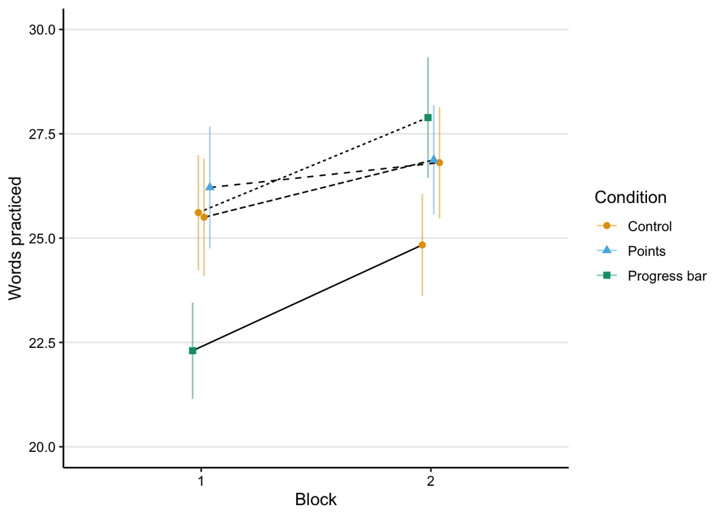

```r
p_learn_words <- plot_data(d_learn_words_agg, words_mean, words_se, "Words practiced") +
  scale_y_continuous(limits = c(20, 30))

p_learn_words
```

### Fit model

Prepare data for modelling by mean-centering categorical predictors:

```r
d_learn_words_m <- d_learn_words |>
  ungroup() |>
  mutate(exp_group_c = ifelse(exp_group == "score", 0, 1),
         exp_group_c = exp_group_c - mean(exp_group_c),
         gamified_first_c = gamified_first - mean(gamified_first))
```

```r
m_learn_words <- lmer(words_seen ~ gamified +
                       gamified:exp_group_c +
                       gamified:gamified_first_c +
                       gamified:gamified_first_c:exp_group_c +
                       (1 | subject),
                     data = d_learn_words_m)

summary(m_learn_words)
```

```
Linear mixed model fit by REML. t-tests use Satterthwaite's method [
lmerModLmerTest]
Formula:
words_seen ~ gamified + gamified:exp_group_c + gamified:gamified_first_c +
    gamified:gamified_first_c:exp_group_c + (1 | subject)
   Data: d_learn_words_m

REML criterion at convergence: 2201.5

Scaled residuals:
     Min       1Q   Median       3Q      Max
-2.22686 -0.49906  0.05179  0.50386  2.35412

Random effects:
 Groups   Name        Variance Std.Dev.
 subject  (Intercept) 57.91    7.610
 Residual             17.11    4.137
Number of obs: 332, groups:  subject, 166

Fixed effects:
                                             Estimate Std. Error         df
(Intercept)                                 25.725008   0.672290 203.027802
gamifiedTRUE                                 0.002888   0.454075 162.000006
gamifiedFALSE:exp_group_c                   -1.017908   1.346145 203.027801
gamifiedTRUE:exp_group_c                    -1.655928   1.346145 203.027801
gamifiedFALSE:gamified_first_c               0.317483   1.349388 203.027802
gamifiedTRUE:gamified_first_c               -3.005740   1.349388 203.027802
gamifiedFALSE:exp_group_c:gamified_first_c  -2.082412   2.702006 203.027802
gamifiedTRUE:exp_group_c:gamified_first_c   -4.924329   2.702006 203.027802
                                           t value Pr(>|t|)
(Intercept)                                 38.265   <2e-16 ***
gamifiedTRUE                                 0.006   0.9949
gamifiedFALSE:exp_group_c                   -0.756   0.4504
gamifiedTRUE:exp_group_c                    -1.230   0.2201
gamifiedFALSE:gamified_first_c               0.235   0.8142
gamifiedTRUE:gamified_first_c               -2.227   0.0270 *
gamifiedFALSE:exp_group_c:gamified_first_c  -0.771   0.4418
gamifiedTRUE:exp_group_c:gamified_first_c   -1.822   0.0699 .
---
Signif. codes:  0 '***' 0.001 '**' 0.01 '*' 0.05 '.' 0.1 ' ' 1

Correlation of Fixed Effects:
              (Intr) gmTRUE gmfdFALSE:x__ gmfdTRUE:x__ gmfdFALSE:g__
gamifidTRUE   -0.338
gmfdFALSE:x__  0.000  0.000
gmfdTRUE:x__   0.000  0.000  0.772
gmfdFALSE:g__  0.000  0.000 -0.004        -0.003
gmfdTRUE:g__   0.000  0.000 -0.003        -0.004        0.772
gFALSE:__:_   -0.004  0.001  0.000         0.000        0.001
gTRUE:__:__   -0.003 -0.001  0.000         0.000        0.001
              gmfdTRUE:g__ gFALSE:__:
gamifidTRUE
gmfdFALSE:x__
gmfdTRUE:x__
gmfdFALSE:g__
gmfdTRUE:g__
gFALSE:__:_    0.001
gTRUE:__:__    0.001        0.772
```

```r
print_model_table(m_learn_words)
```

| Effect | Estimate | SE | df | t-value | p-value |
| --- | --- | --- | --- | --- | --- |
| Intercept (Control) | 25.725 | 0.672 | 203.03 | 38.26 | <.001 |
| Gamification | 0.003 | 0.454 | 162.00 | 0.01 | .995 |
| Type of gamification (Progress bar - Points) | -1.656 | 1.346 | 203.03 | -1.23 | .220 |
| Type of gamification on Control (Progress bar - Points) | -1.018 | 1.346 | 203.03 | -0.76 | .450 |
| Block on gamification (1 - 2) | -3.006 | 1.349 | 203.03 | -2.23 | .027 |
| Block on Control (2 - 1) | 0.317 | 1.349 | 203.03 | 0.24 | .814 |
| Type of gamification; block difference (Block 1 - Block 2) | -4.924 | 2.702 | 203.03 | -1.82 | .070 |
| Type of gamification on Control; block difference (Block 2 - Block 1) | -2.082 | 2.702 | 203.03 | -0.77 | .442 |

### Fitted values

```r
d_model_fit <- crossing(
  gamified = TRUE,
  exp_group_c = 0,
  gamified_first_c = sort(unique(d_learn_words_m$gamified_first_c))
)

d_model_fit$model_fit <- predict(m_learn_words,
                                 newdata = d_model_fit,
                                 re.form = NA,
                                 type = "response")

d_model_fit
```

| gamified | exp_group_c | gamified_first_c | model_fit |
| --- | --- | --- | --- |
| TRUE | 0 | -0.5421687 | 27.35751 |
| TRUE | 0 | 0.4578313 | 24.35177 |

### Visualise fitted model

```r
p_learn_words_m <- plot_model_fit(m_learn_words, d_learn_words_m, y_lab = "Words practiced") +
  scale_y_continuous(limits = c(20, 30))
```

```
  block    condition gamified gamified_first exp_group gamified_first_c
1     1      Control    FALSE          FALSE      both       -0.5421687
2     1      Control    FALSE          FALSE     score       -0.5421687
3     1       Points     TRUE           TRUE     score        0.4578313
4     1 Progress bar     TRUE           TRUE      both        0.4578313
5     2      Control    FALSE           TRUE      both        0.4578313
6     2      Control    FALSE           TRUE     score        0.4578313
7     2       Points     TRUE          FALSE     score       -0.5421687
8     2 Progress bar     TRUE          FALSE      both       -0.5421687
  exp_group_c pred_val     exp_order     type
1   0.5240964 25.61111  Control—Both  Control
2  -0.4759036 25.50000 Control—Score  Control
3  -0.4759036 26.21277 Score—Control Gamified
4   0.5240964 22.30233  Both—Control Gamified
5   0.5240964 24.83721  Both—Control  Control
6  -0.4759036 26.80851 Score—Control  Control
7  -0.4759036 26.87500 Control—Score Gamified
8   0.5240964 27.88889  Control—Both Gamified
```

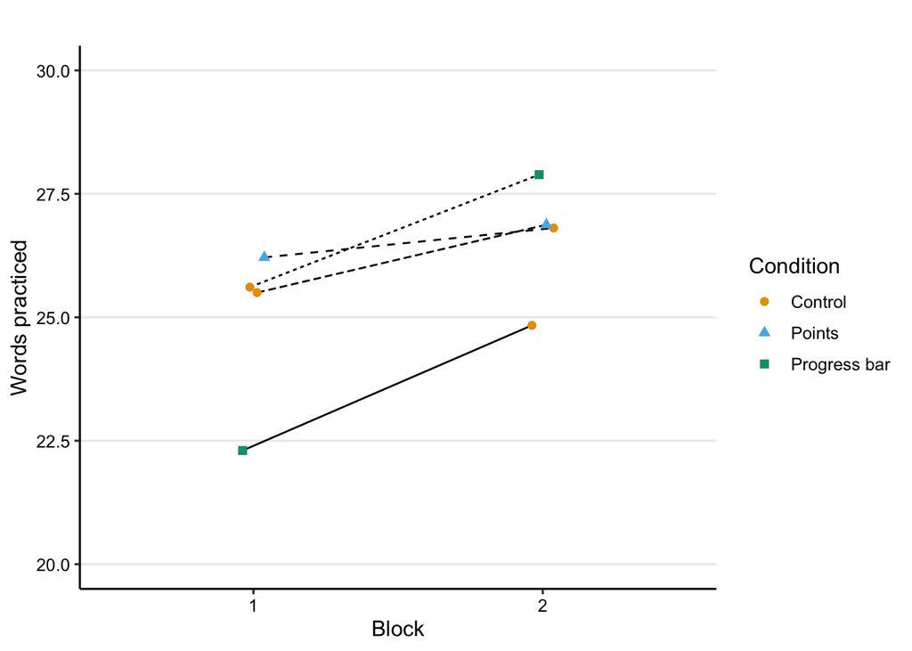

```r
p_learn_words_m
```

## Completed trials

### Prepare data

```r
d_learn_trials <- d_learn |>
  group_by(subject, exp_group, block, condition, gamified, gamified_first) |>
  summarise(n_trials = n())
```

```
'condition', 'gamified'. You can override using the `.groups` argument.
```

```r
d_learn_trials_agg <- d_learn_trials |>
  group_by(block, condition, gamified, gamified_first, exp_group) |>
  summarise(trials_mean = mean(n_trials, na.rm = T),
            trials_se = sd(n_trials, na.rm = T)/sqrt(n())) |>
  ungroup() |>
  add_experiment_cols()
```

```
'gamified_first'. You can override using the `.groups` argument.
```

### Visualise data

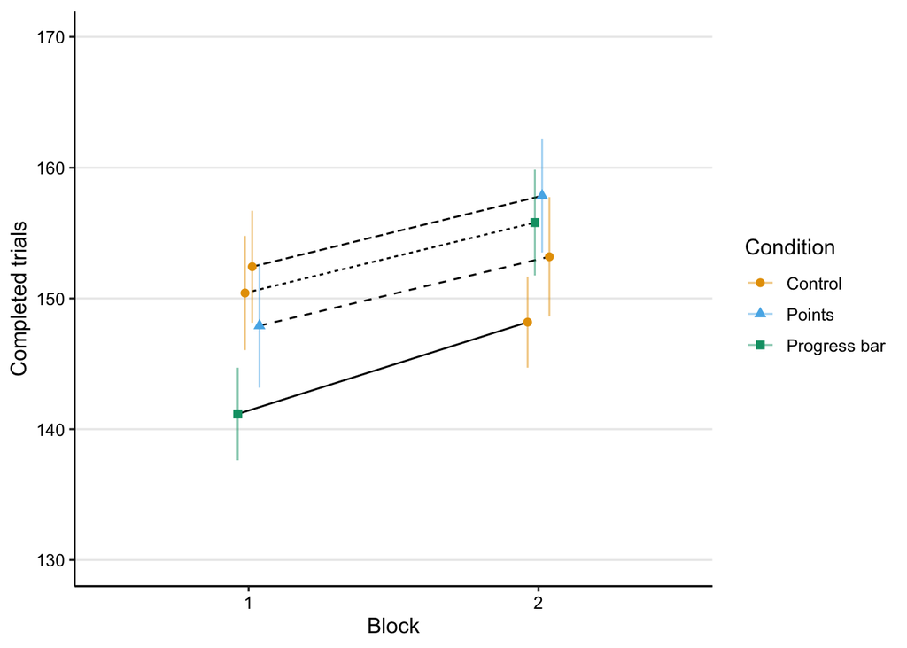

```r
p_learn_trials <- plot_data(d_learn_trials_agg, trials_mean, trials_se, "Completed trials") +
  scale_y_continuous(limits = c(130, 170))

p_learn_trials
```

### Fit model

Prepare data for modelling by mean-centering categorical predictors:

```r
d_learn_trials_m <- d_learn_trials |>
  ungroup() |>
  mutate(exp_group_c = ifelse(exp_group == "score", 0, 1),
         exp_group_c = exp_group_c - mean(exp_group_c),
         gamified_first_c = gamified_first - mean(gamified_first))
```

```r
m_learn_trials <- lmer(n_trials ~ gamified +
                       gamified:exp_group_c +
                       gamified:gamified_first_c +
                       gamified:gamified_first_c:exp_group_c +
                       (1 | subject),
                     data = d_learn_trials_m)

summary(m_learn_trials)
```

```
Linear mixed model fit by REML. t-tests use Satterthwaite's method [
lmerModLmerTest]
Formula:
n_trials ~ gamified + gamified:exp_group_c + gamified:gamified_first_c +
    gamified:gamified_first_c:exp_group_c + (1 | subject)
   Data: d_learn_trials_m

REML criterion at convergence: 2932.7

Scaled residuals:
     Min       1Q   Median       3Q      Max
-2.34679 -0.49538 -0.03198  0.45220  2.45632

Random effects:
 Groups   Name        Variance Std.Dev.
 subject  (Intercept) 586.6    24.22
 Residual             156.2    12.50
Number of obs: 332, groups:  subject, 166

Fixed effects:
                                           Estimate Std. Error       df t value
(Intercept)                                151.1115     2.1153 199.5462  71.439
gamifiedTRUE                                -0.8356     1.3717 162.0000  -0.609
gamifiedFALSE:exp_group_c                   -3.6333     4.2355 199.5462  -0.858
gamifiedTRUE:exp_group_c                    -4.5968     4.2355 199.5462  -1.085
gamifiedFALSE:gamified_first_c              -0.6598     4.2457 199.5462  -0.155
gamifiedTRUE:gamified_first_c              -12.1755     4.2457 199.5462  -2.868
gamifiedFALSE:exp_group_c:gamified_first_c  -2.9971     8.5015 199.5462  -0.353
gamifiedTRUE:exp_group_c:gamified_first_c   -4.7077     8.5015 199.5462  -0.554
                                           Pr(>|t|)
(Intercept)                                 < 2e-16 ***
gamifiedTRUE                                0.54326
gamifiedFALSE:exp_group_c                   0.39202
gamifiedTRUE:exp_group_c                    0.27909
gamifiedFALSE:gamified_first_c              0.87665
gamifiedTRUE:gamified_first_c               0.00458 **
gamifiedFALSE:exp_group_c:gamified_first_c  0.72481
gamifiedTRUE:exp_group_c:gamified_first_c   0.58037
---
Signif. codes:  0 '***' 0.001 '**' 0.01 '*' 0.05 '.' 0.1 ' ' 1

Correlation of Fixed Effects:
              (Intr) gmTRUE gmfdFALSE:x__ gmfdTRUE:x__ gmfdFALSE:g__
gamifidTRUE   -0.324
gmfdFALSE:x__  0.000  0.000
gmfdTRUE:x__   0.000  0.000  0.790
gmfdFALSE:g__  0.000  0.000 -0.004        -0.003
gmfdTRUE:g__   0.000  0.000 -0.003        -0.004        0.790
gFALSE:__:_   -0.004  0.001  0.000         0.000        0.001
gTRUE:__:__   -0.003 -0.001  0.000         0.000        0.001
              gmfdTRUE:g__ gFALSE:__:
gamifidTRUE
gmfdFALSE:x__
gmfdTRUE:x__
gmfdFALSE:g__
gmfdTRUE:g__
gFALSE:__:_    0.001
gTRUE:__:__    0.001        0.790
```

```r
print_model_table(m_learn_trials)
```

| Effect | Estimate | SE | df | t-value | p-value |
| --- | --- | --- | --- | --- | --- |
| Intercept (Control) | 151.111 | 2.115 | 199.55 | 71.44 | <.001 |
| Gamification | -0.836 | 1.372 | 162.00 | -0.61 | .543 |
| Type of gamification (Progress bar - Points) | -4.597 | 4.235 | 199.55 | -1.09 | .279 |
| Type of gamification on Control (Progress bar - Points) | -3.633 | 4.235 | 199.55 | -0.86 | .392 |
| Block on gamification (1 - 2) | -12.175 | 4.246 | 199.55 | -2.87 | .005 |
| Block on Control (2 - 1) | -0.660 | 4.246 | 199.55 | -0.16 | .877 |
| Type of gamification; block difference (Block 1 - Block 2) | -4.708 | 8.501 | 199.55 | -0.55 | .580 |
| Type of gamification on Control; block difference (Block 2 - Block 1) | -2.997 | 8.501 | 199.55 | -0.35 | .725 |

### Fitted values

```r
d_model_fit <- crossing(
  gamified = TRUE,
  exp_group_c = 0,
  gamified_first_c = sort(unique(d_learn_trials_m$gamified_first_c))
)

d_model_fit$model_fit <- predict(m_learn_trials,
                                 newdata = d_model_fit,
                                 re.form = NA,
                                 type = "response")

d_model_fit
```

| gamified | exp_group_c | gamified_first_c | model_fit |
| --- | --- | --- | --- |
| TRUE | 0 | -0.5421687 | 156.8770 |
| TRUE | 0 | 0.4578313 | 144.7015 |

### Visualise fitted model

```r
p_learn_trials_m <- plot_model_fit(m_learn_trials, d_learn_trials_m, y_lab = "Trials completed") +
  scale_y_continuous(limits = c(130, 170))
```

```
  block    condition gamified gamified_first exp_group gamified_first_c
1     1      Control    FALSE          FALSE      both       -0.5421687
2     1      Control    FALSE          FALSE     score       -0.5421687
3     1       Points     TRUE           TRUE     score        0.4578313
4     1 Progress bar     TRUE           TRUE      both        0.4578313
5     2      Control    FALSE           TRUE      both        0.4578313
6     2      Control    FALSE           TRUE     score        0.4578313
7     2       Points     TRUE          FALSE     score       -0.5421687
8     2 Progress bar     TRUE          FALSE      both       -0.5421687
  exp_group_c pred_val     exp_order     type
1   0.5240964 150.4167  Control—Both  Control
2  -0.4759036 152.4250 Control—Score  Control
3  -0.4759036 147.9149 Score—Control Gamified
4   0.5240964 141.1628  Both—Control Gamified
5   0.5240964 148.1860  Both—Control  Control
6  -0.4759036 153.1915 Score—Control  Control
7  -0.4759036 157.8500 Control—Score Gamified
8   0.5240964 155.8056  Control—Both Gamified
```

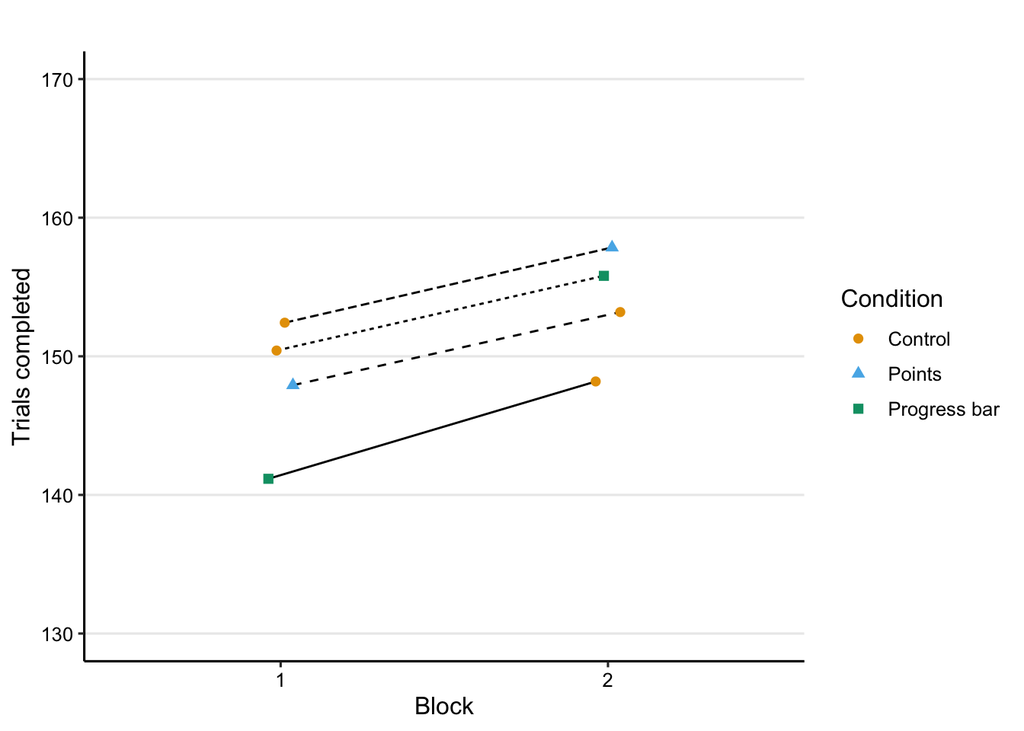

```r
p_learn_trials_m
```

## Conclusions

- Gamified feedback had no effect on response accuracy during practice. Response accuracy was slightly higher in the Control condition for participants in the Points group than for participants in the Progress bar group, possibly due to group differences in spite of random assignment.
- Correct responses were slower during practice with gamified feedback than in the control condition, particularly so in Block 1.
- There were no overall effects of the gamification manipulation on total score, number of words practiced, or number of trials completed. However, in the gamified conditions, these outcomes were all better in Block 2 than in Block 1.

## Combined plot

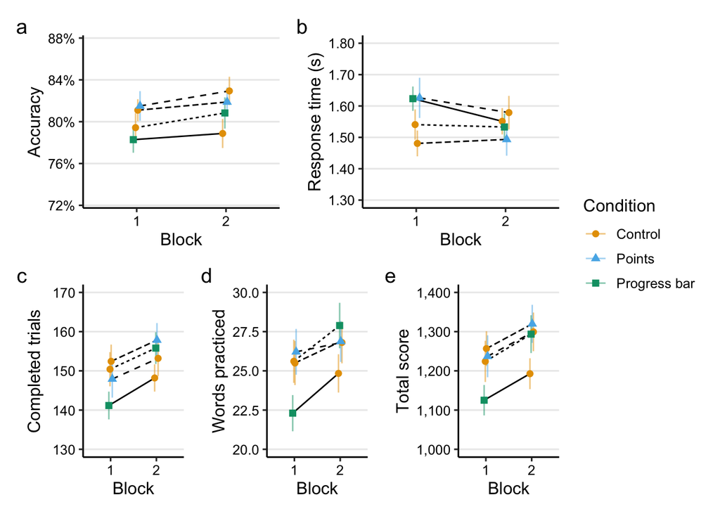

```r
((p_learn_acc | p_learn_rt) / (p_learn_trials | p_learn_words | p_learn_score)) +
  plot_layout(guides = "collect") +
  plot_annotation(tag_levels = "a")
```

```r
ggsave(here("output", "practice_performance_all.png"), width = 6, height = 5)
```

Streamlined version:

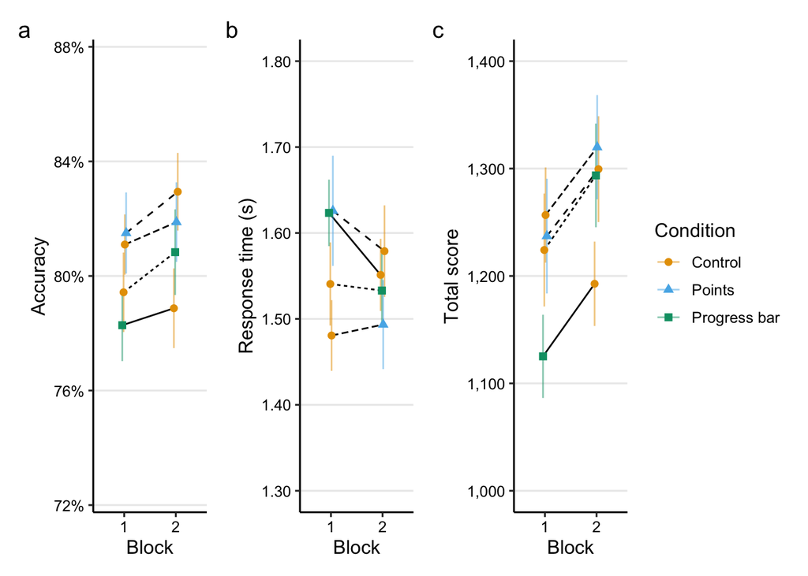

```r
(p_learn_acc | p_learn_rt | p_learn_score) +
  plot_layout(guides = "collect") +
  plot_annotation(tag_levels = "a")
```

```r
ggsave(here("output", "practice_performance.png"), width = 8, height = 3)
```